# MLSeq Notebook

## Project 2: Micro-RNA Prediction

This project focuses on predicting important microRNAs (miRNAs) involved in the development of disease, specifically Acute Respiratory Distress Syndrome (ARDS), by analyzing miRNA and mRNA data from patients with ARDS. The data was sourced from the article [“T cell dysfunction in elderly ARDS patients based on miRNA and mRNA integration analysis”](https://www.frontiersin.org/journals/immunology/articles/10.3389/fimmu.2024.1368446/full). The objective is to identify miRNAs that might play a critical role in the pathogenesis and severity of ARDS.

### Background

Acute Respiratory Distress Syndrome (ARDS) is a life-threatening condition that results in respiratory failure, often occurring in critically ill patients. Despite its significant impact, the molecular mechanisms underlying ARDS are not fully understood. In this study, both mRNA and miRNA were sequenced from patients with ARDS and healthy controls, with the goal of better understanding the pathogenesis of ARDS.

```r
#BiocManager::install("MLSeq")
library(MLSeq)
library(tximport)
library(tidyverse)
library(DESeq2)
set.seed(1111)
```

```r
setwd("/Users/dariakilina/GitHub/RNAseq_projects/micro-RNA")
counts_dir = "./counts/"
counts_files = list.files(counts_dir, pattern = "*.tsv")
counts_files %>% head
```

```
[1] "SRR26050650_GSM7778640_H16_miRNA-seq_Homo_sapiens_miRNA-Seq.tsv"
[2] "SRR26050651_GSM7778639_H25_miRNA-seq_Homo_sapiens_miRNA-Seq.tsv"
[3] "SRR26050652_GSM7778638_H24_miRNA-seq_Homo_sapiens_miRNA-Seq.tsv"
[4] "SRR26050653_GSM7778637_H22_miRNA-seq_Homo_sapiens_miRNA-Seq.tsv"
[5] "SRR26050654_GSM7778636_H21_miRNA-seq_Homo_sapiens_miRNA-Seq.tsv"
[6] "SRR26050655_GSM7778635_H20_miRNA-seq_Homo_sapiens_miRNA-Seq.tsv"
```

[output not shown]

tibble() is used to create a data frame-like object in R. Defining the condition column based on a pattern matching logic applied to the filenames. The sample_table must include: • fileName: The names of the count files. • condition: The experimental condition associated with each sample (e.g., “A - affected” or “H-healthy”).

```r
sample_table = tibble(fileName = counts_files,
                      sampleName = counts_files,
                      condition = ifelse(str_detect(fileName, "A[0-9]+"), "A", "H") %>% factor(levels = c("H", "A")))
sample_table %>% head
```

| fileName | sampleName | condition |
| --- | --- | --- |
| SRR26050650_GSM7778640_H16_miRNA-seq_Homo_sapiens_miRNA-Seq.tsv | SRR26050650_GSM7778640_H16_miRNA-seq_Homo_sapiens_miRNA-Seq.tsv | H |
| SRR26050651_GSM7778639_H25_miRNA-seq_Homo_sapiens_miRNA-Seq.tsv | SRR26050651_GSM7778639_H25_miRNA-seq_Homo_sapiens_miRNA-Seq.tsv | H |
| SRR26050652_GSM7778638_H24_miRNA-seq_Homo_sapiens_miRNA-Seq.tsv | SRR26050652_GSM7778638_H24_miRNA-seq_Homo_sapiens_miRNA-Seq.tsv | H |
| SRR26050653_GSM7778637_H22_miRNA-seq_Homo_sapiens_miRNA-Seq.tsv | SRR26050653_GSM7778637_H22_miRNA-seq_Homo_sapiens_miRNA-Seq.tsv | H |
| SRR26050654_GSM7778636_H21_miRNA-seq_Homo_sapiens_miRNA-Seq.tsv | SRR26050654_GSM7778636_H21_miRNA-seq_Homo_sapiens_miRNA-Seq.tsv | H |
| SRR26050655_GSM7778635_H20_miRNA-seq_Homo_sapiens_miRNA-Seq.tsv | SRR26050655_GSM7778635_H20_miRNA-seq_Homo_sapiens_miRNA-Seq.tsv | H |

This code creates a DESeqDataSet object for RNA-seq data analysis using DESeq2. The DESeqDataSetFromHTSeqCount function is used to prepare count data (obtained from HTSeq-count or similar tools) for differential expression analysis with DESeq2. design = ~ condition, comparing groups “A” vs. “H”

```r
ddsHTSeq <- DESeqDataSetFromHTSeqCount(sampleTable = sample_table,
                                       directory = counts_dir,
                                       design= ~ condition)
ddsHTSeq
```

```
class: DESeqDataSet
dim: 63187 49
metadata(1): version
assays(1): counts
rownames(63187): ENSG00000000003.16 ENSG00000000005.6 ... ENSG00000293559.1 ENSG00000293560.1
rowData names(0):
colnames(49): SRR26050650_GSM7778640_H16_miRNA-seq_Homo_sapiens_miRNA-Seq.tsv
  SRR26050651_GSM7778639_H25_miRNA-seq_Homo_sapiens_miRNA-Seq.tsv ...
  SRR26050697_GSM7778593_A6_miRNA-seq_Homo_sapiens_miRNA-Seq.tsv
  SRR26050698_GSM7778592_A1_miRNA-seq_Homo_sapiens_miRNA-Seq.tsv
colData names(1): condition
```

Extracts raw count data from the DESeq2 object (ddsHTSeq) created earlier using DESeqDataSetFromHTSeqCount. This raw count data contains gene expression counts for all genes across all samples.

```r
count_data = counts(ddsHTSeq)
count_data %>% str
```

```
 int [1:63187, 1:49] 0 0 0 0 0 0 0 0 1 0 ...
 - attr(*, "dimnames")=List of 2
  ..$ : chr [1:63187] "ENSG00000000003.16" "ENSG00000000005.6" "ENSG00000000419.14" "ENSG00000000457.14" ...
  ..$ : chr [1:49] "SRR26050650_GSM7778640_H16_miRNA-seq_Homo_sapiens_miRNA-Seq.tsv" "SRR26050651_GSM7778639_H25_miRNA-seq_Homo_sapiens_miRNA-Seq.tsv" "SRR26050652_GSM7778638_H24_miRNA-seq_Homo_sapiens_miRNA-Seq.tsv" "SRR26050653_GSM7778637_H22_miRNA-seq_Homo_sapiens_miRNA-Seq.tsv" ...
```

Calculates the variance across samples (columns) for each gene (rows) and sorts the calculated variances in descending order, so the most variable genes are at the top of the list.

```r
vars <- sort(apply(count_data, 1, var, na.rm = TRUE), decreasing = TRUE)
vars %>% head
```

```
ENSG00000203875.13 ENSG00000234741.10  ENSG00000199994.1  ENSG00000201098.1  ENSG00000199753.1  ENSG00000207031.1
       48339899912         1455479220         1427330938         1423260299          837394746          446029199
```

Selects the first 100 genes (by name) with the highest variance from the sorted vars.These genes are considered the most hypervariable, making them potentially interesting for downstream statistical analysis.

```r
data <- count_data[names(vars)[1:100], ]
data %>% str
```

```
 int [1:100, 1:49] 129855 19797 33574 46814 9827 11639 6532 3350 9528 5231 ...
 - attr(*, "dimnames")=List of 2
  ..$ : chr [1:100] "ENSG00000203875.13" "ENSG00000234741.10" "ENSG00000199994.1" "ENSG00000201098.1" ...
  ..$ : chr [1:49] "SRR26050650_GSM7778640_H16_miRNA-seq_Homo_sapiens_miRNA-Seq.tsv" "SRR26050651_GSM7778639_H25_miRNA-seq_Homo_sapiens_miRNA-Seq.tsv" "SRR26050652_GSM7778638_H24_miRNA-seq_Homo_sapiens_miRNA-Seq.tsv" "SRR26050653_GSM7778637_H22_miRNA-seq_Homo_sapiens_miRNA-Seq.tsv" ...
```

Uses the sample_table (previously defined) and selects the condition column. transmute() creates a new tibble/dataframe that contains only the condition column.

```r
class = sample_table %>% transmute(condition)
class %>% str
```

```
tibble [49 × 1] (S3: tbl_df/tbl/data.frame)
 $ condition: Factor w/ 2 levels "H","A": 1 1 1 1 1 1 1 1 1 1 ...
```

```r
table(class$condition)
```

```
 H  A
15 34
```

Calculates 30% of the number of columns (samples) in the data matrix. ncol(data): Number of columns (samples) in data. ceiling() ensures that the value is rounded up to the nearest whole number. This number (nTest) will determine how many samples (or subsets of genes) will be randomly selected.

```r
nTest <- ceiling(ncol(data) * 0.3)
nTest
```

```
[1] 15
```

Randomly samples nTest column indices from the total number of columns in data. This is likely to randomize which subset of samples is used for downstream analysis. ind: Indices of randomly sampled columns (representing samples).

```r
ind <- sample(ncol(data), nTest, FALSE)
ind
```

```
 [1] 44 26 36  6 38 48 31 39  1 13 24  2 18 23 21
```

Split the dataset into training and testing sets: Based on randomly selected indices (ind) from the data. And adding +1 ensures that zero counts do not interfere with statistical analysis

Split the class labels into training and testing subsets corresponding to data.train and data.test.

```r
data.train <- as.matrix(data[ ,-ind] + 1)
data.test <- as.matrix(data[ ,ind] + 1)
classtr <- class[-ind, ]
classts <- class[ind, ]
```

Сreate a DESeqDataSet objects (train and test) from a count matrix and sample metadata. • data.train and data.test are numeric matrices where the rows are genes and the columns are samples. • classtr and classts contain information about which groups the samples belong to

```r
data.trainS4 = DESeqDataSetFromMatrix(countData = data.train, colData = classtr,
design = formula(~condition))
data.testS4 = DESeqDataSetFromMatrix(countData = data.test, colData = classts,
design = formula(~condition))
```

```
method = "pam": NSC method (Prediction Analysis for Microarrays)
```

```r
fit.NSC <- classify(data = data.trainS4, method = "pam",
preProcessing = "deseq-vst", ref = "H", tuneLength = 10,
control = trainControl(method = "repeatedcv", number = 5,
repeats = 10, classProbs = TRUE))
```

[output not shown]

```r
show(fit.NSC)
```

```
  An object of class "MLSeq"
  Model Description: Nearest Shrunken Centroids (pam)

            Method  :  pam

       Accuracy(%)  :  88.24
    Sensitivity(%)  :  72.73
    Specificity(%)  :  95.65

  Reference Class   :  H
```

Show the results of training the model, including final hyperparameter settings and performance on training data.

```r
trained(fit.NSC)
```

```
Nearest Shrunken Centroids

 34 samples
100 predictors
  2 classes: 'H', 'A'

No pre-processing
Resampling: Cross-Validated (5 fold, repeated 10 times)
Summary of sample sizes: 28, 27, 27, 27, 27, 28, ...
Resampling results across tuning parameters:

  threshold   Accuracy   Kappa
  0.09555484  0.8384524  0.66634373
  0.38221935  0.8434524  0.67252473
  0.66888386  0.8813095  0.74646358
  0.95554837  0.8953571  0.77126696
  1.24221288  0.9019048  0.75685213
  1.52887739  0.7501190  0.27386968
  1.81554190  0.6880952  0.04705882
  2.10220642  0.6766667  0.00000000
  2.38887093  0.6766667  0.00000000
  2.67553544  0.6766667  0.00000000

Accuracy was used to select the optimal model using the largest value.
The final value used for the model was threshold = 1.242213.
```

[output not shown]

Сross-validation parameters for two different types of classifiers: continuous (for methods that work with continuous data) and discrete (for methods that work with discrete or categorical data)

```r
ctrl.continuous <- trainControl(method = "repeatedcv", number = 5, repeats = 10, classProbs = TRUE)
ctrl.discrete <- discreteControl(method = "repeatedcv", number = 5, repeats = 10,
tuneLength = 10)
```

This code trains and compares multiple classifiers to determine which one classifies data better with cross-validation params.

```r
# availableMethods()
```

The SVM algorithm works by finding the optimal hyperplane (a decision boundary) that best separates the data into different classes. In two dimensions, this is a line, while in higher dimensions, it’s a hyperplane. • The idea is to find the hyperplane that maximizes the margin, which is the distance between the nearest data points of each class (called support vectors). Support vectors are the data points that are closest to the hyperplane and help define the margin. These points are critical in constructing the optimal hyperplane. package ‘kernlab’ is needed

```r
fit.svm <- classify(data = data.trainS4, method = "svmRadial",
preProcessing = "deseq-vst", ref = "H", tuneLength = 10,
control = ctrl.continuous)
fit.svm
```

```
  An object of class "MLSeq"
  Model Description: Support Vector Machines with Radial Basis Function Kernel (svmRadial)

            Method  :  svmRadial

       Accuracy(%)  :  97.06
    Sensitivity(%)  :  90.91
    Specificity(%)  :  100

  Reference Class   :  H
```

```r
fit.plda <- classify(data = data.trainS4, method = "PLDA", normalize = "deseq",
ref = "H", control = ctrl.discrete)
fit.plda2 <- classify(data = data.trainS4, method = "PLDA2", normalize = "deseq",
ref = "H", control = ctrl.discrete)
fit.nblda <- classify(data = data.trainS4, method = "NBLDA", normalize = "deseq",
ref = "H", control = ctrl.discrete)
fit.plda2
```

```
  An object of class "MLSeq"
  Model Description: Poisson Linear Discriminant Analysis with Power Transformation (PLDA2)

            Method  :  PLDA2

       Accuracy(%)  :  85.29
    Sensitivity(%)  :  90.91
    Specificity(%)  :  82.61

  Reference Class   :  H
```

```r
models <- list(
  SVM = fit.svm,
  NSC = fit.NSC,
  PLDA = fit.plda,
  PLDA2 = fit.plda2,
  NBLDA = fit.nblda
)
```

Graphs showing how the performance of a model varies with the number of features or tuning parameters used.

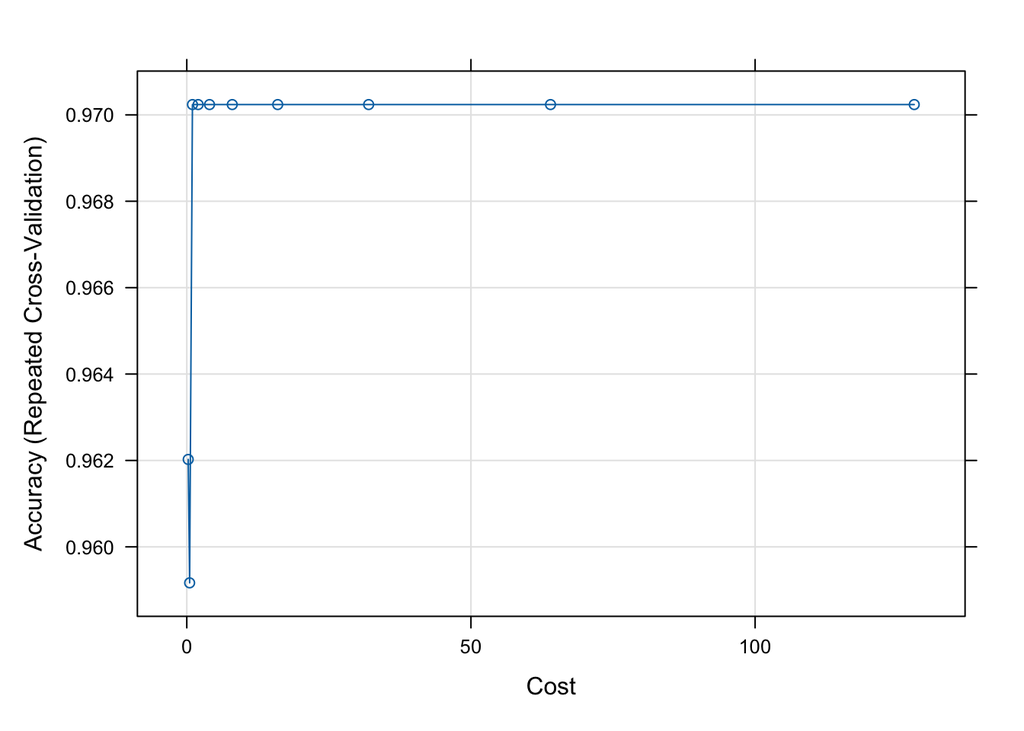

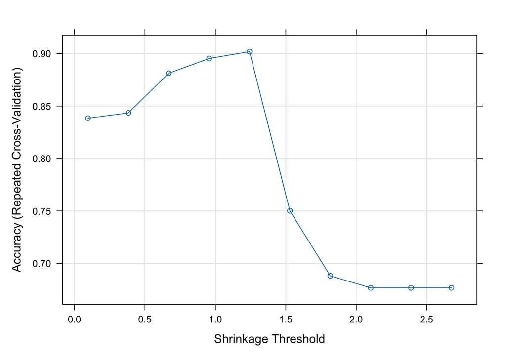

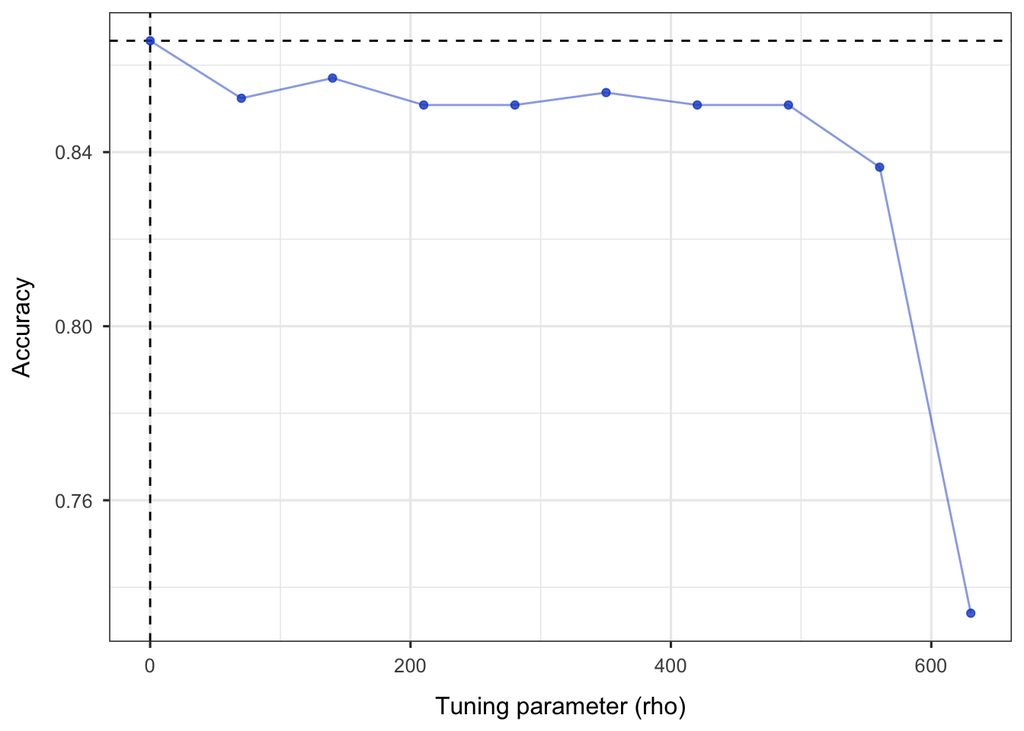

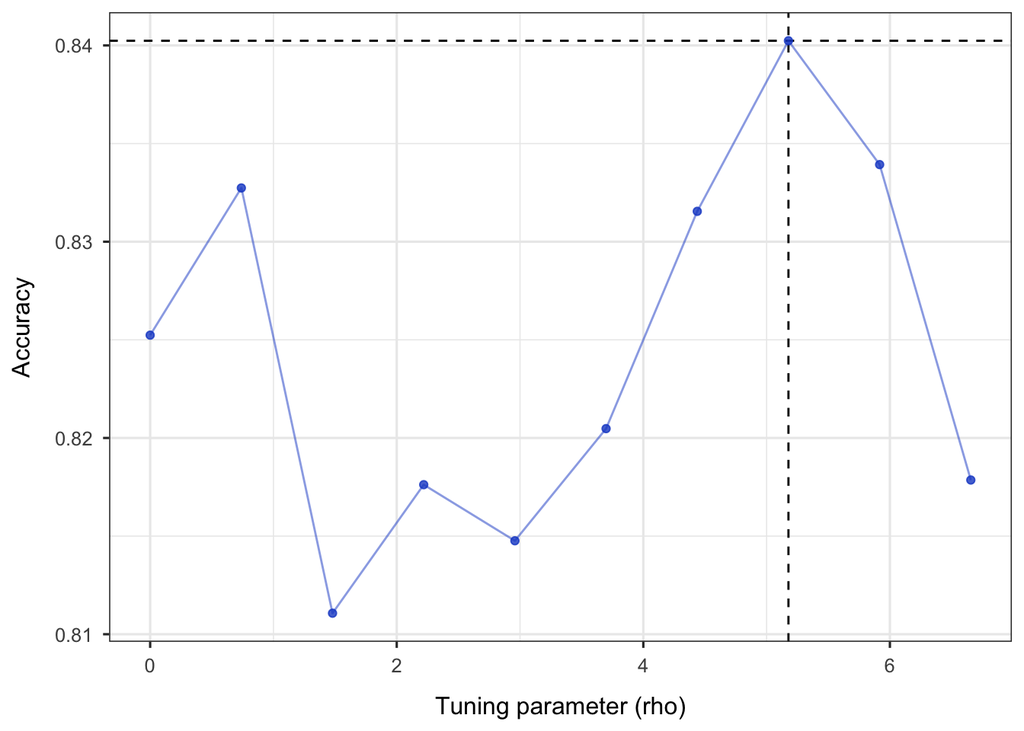

```r
sapply(models, plot) #don't work for nblda
```

Comparison of models

```r
extract_metric <- function(model, metric_name) {
  output <- capture.output(model)
  metric_line <- grep(metric_name, output, value = TRUE)
  metric_value <- as.numeric(gsub(paste0(".*", metric_name, "\\(%\\)  :\\s*"), "", metric_line))
  return(metric_value)
}

accuracies <- sapply(models, extract_metric, metric_name = "Accuracy")
sensitivities <- sapply(models, extract_metric, metric_name = "Sensitivity")
specificities <- sapply(models, extract_metric, metric_name = "Specificity")

df <- data.frame(
  Accuracy = accuracies,
  Sensitivity = sensitivities,
  Specificity = specificities
)

print(df)
```

```
      Accuracy Sensitivity Specificity
SVM      97.06       90.91      100.00
NSC      88.24       72.73       95.65
PLDA     85.29       90.91       82.61
PLDA2    85.29       90.91       82.61
NBLDA    82.35       81.82       82.61
```

Check predictions for NSC

```r
pred.NSC <- predict(fit.NSC, data.testS4)
```

```
variance of dispersion residuals not estimated (necessary only for differential expression calling)
```

```r
pred.NSC <- relevel(pred.NSC, ref = "H")
actual <- relevel(classts$condition, ref = "H")
tbl <- table(Predicted = pred.NSC, Actual = actual)
confusionMatrix(tbl, positive = "H")
```

```
Confusion Matrix and Statistics

         Actual
Predicted  H  A
        H  3  0
        A  1 11

               Accuracy : 0.9333
                 95% CI : (0.6805, 0.9983)
    No Information Rate : 0.7333
    P-Value [Acc > NIR] : 0.06157

                  Kappa : 0.8148

 Mcnemar's Test P-Value : 1.00000

            Sensitivity : 0.7500
            Specificity : 1.0000
         Pos Pred Value : 1.0000
         Neg Pred Value : 0.9167
             Prevalence : 0.2667
         Detection Rate : 0.2000
   Detection Prevalence : 0.2000
      Balanced Accuracy : 0.8750

       'Positive' Class : H
```

```r
pred.svm <- relevel(pred.svm, ref = "H")
actual <- relevel(classts$condition, ref = "H")
tbl <- table(Predicted = pred.svm, Actual = actual)
confusionMatrix(tbl, positive = "H")
```

[output not shown]

```
Confusion Matrix and Statistics

         Actual
Predicted  H  A
        H  0  0
        A  4 11

               Accuracy : 0.7333
                 95% CI : (0.449, 0.9221)
    No Information Rate : 0.7333
    P-Value [Acc > NIR] : 0.6304

                  Kappa : 0

 Mcnemar's Test P-Value : 0.1336

            Sensitivity : 0.0000
            Specificity : 1.0000
         Pos Pred Value :    NaN
         Neg Pred Value : 0.7333
             Prevalence : 0.2667
         Detection Rate : 0.0000
   Detection Prevalence : 0.0000
      Balanced Accuracy : 0.5000

       'Positive' Class : H
```

```r
# Some methods allow selecting markers
selectedGenes(fit.plda2)
```

```
[1] "ENSG00000203875.13" "ENSG00000239043.1"
```

[output not shown]